# *MSc Ecology and Data Science Thesis* Functional traits of trees through forest successional time - Paper narrative, data exploration, preparation, and analysis

Merlin Weiss

Status: 2024-06-18

# Introduction

- **Ecological significance of forests**: Forests are biodiversity hotspots and provide vital ecosystem services, such as carbon storage, regulation of water cycles, and prevention of soil degradation.
- **Successional dynamics:** Introduce forest succession, focus on the transition from pioneer to climax communities and the changes in species composition over time. Talks about stages of primary and secondary succession.
- **Functional traits of trees:** Introduce the idea of functional traits and their role in determining tree species’ strategies for growth, reproduction, and survival. Then make the link to why functional traits are more suited to understand and predict successional trajectories than taxonomic diversity metrics.
- **Threats to (forest) biodiversity and why predictions are important**: Talk about the main threats to forests and why this may have wide ranging effects on global biodiversity and also human health (link to ecosystem services). Introduce observed and predicted effects of these threats (especially climate change) on forest dynamics, e.g., *forest phenology*.

## Objective and hypotheses

**Objective**: Here, we aim to get an insight into [*trends of change*] [*the effect of (covariate) on*] functional traits of trees over successional time.

Potential research (sub-)question (don’t mention in the text):

- **Main:** How do functional traits of trees change through forest successional time?
  - **Sub 1:** How do [*covariates*] (biome, climate change) affect [*traits* or *indices*]?
  - **Sub 2:** How do [*covariates*] (biome, climate change) affect proliferation strategies of trees (acquisitive vs conservative) at different stages of forest succession?
  - **Sub 3:** Are successional trajectories deterministic or variable across different environments/biomes/gradients?

Potential hypotheses :

- Functional traits will shift from acquisitive traits in early succession to conservative traits in late succession (see [Lohbeck et al. 2013](https://esajournals.onlinelibrary.wiley.com/doi/full/10.1890/12-1850.1) and [Faccion et al. 2021](https://ui.adsabs.harvard.edu/abs/2021FMDFE.27951815F/abstract)).
- Successional trajectories in undisturbed environments (check forest management or anthropogenic disturbance) will be more deterministic, with predictable changes in functional traits, while those in disturbed environments will be more chaotic (see e.g., [Marcilio-Silver et al. 2016](https://link.springer.com/article/10.1556/168.2016.17.1.11)).

## Key concepts for the introduction

- **Functional Traits and Ecological Strategies** - Discuss the trade-offs between fast growth (acqusitive traits) and resource conservation (conservative traits)
- **Environmental Filtering** - Discuss the role of abiotic factors (e.g., water availability, light availability) in determining trait distributions.
- **Community Assembly** - Discuss mechanisms driving changes in species composition and functional diversity over time (e.g., niche and dispersal assembly, maybe talk about *Hubble and Unified Neutral Theory* or the *Metacommunity theory*, especially in connection to deterministic vs chaotic trajectories). Generally, talk about distinguishing between predictable successional changes and those driven by random events.
- **Resource-use strategies** - Trees may exhibit traits that aim towards resource acquisition (acquisitive traits: i.g., leafs with high area and short lifespan to increase photosynthetic rate, low wood density to increase growth. Willows (Salix spp.) and Poplars (Populus spp.) are high in these traits) or resource conservation (conservative traits: e.g., low leaf area size and life span to conserve more energy and maximise resource efficiency, high wood density to support structure and reduce damage)

# Data

# Data preparation

## FIA data

We build our fia database by cleaning and summarizing the FIA data of every state to the species per plot level. This entails the following:

- Filtering out dead trees, trees not identified to the species level, plots where the conditions is NOT 1 (see FIA description), non-fixed sampling designs, private ownership, and diameter values not measured at breast height.
- Keeping only the most recent measurement per plot (?)
- Scale numeric variables on tree level by trees per acre (TPA)
- Summarize tree level variables to species per plot level using a weighted mean weighted by BA (basal area)

## Trait data

We complete our database by joining the FIA data per state with the trait data. This entails the following:

- Selecting relevant traits for our analysis. These include traits that indicate resource use strategies and do not change drastically with tree age:
  - **Wood density**: Measures the mass of wood per unit volume, indicating the strength and structural integrity of the wood.
  - **Bark thickness**: The thickness of the tree’s bark, providing protection against physical damage and pathogens.
  - **Stem conduit diameter**: Is related to the efficiency of water transport within the tree.
  - **Seed dry mass**: The mass of a tree’s seeds when dry, indicating investment in reproduction.
  - **Shade tolerance**: The shade tolerance of a tree species as an ecological index (CHECK UNITS)
  - **Leaf N**: The concentration of nitrogen in leaves, reflecting the plant’s investment in photosynthetic proteins.
  - **Specific leaf area**: The leaf area per unit dry mass, indicative of the leaf’s thickness and light-capturing efficiency.

  Some traits are retrieved from the FIA data:
  - **mean_DIA**: The mean tree diameter per FIA plot.
  - **mean_height**: The mean tree height per FIA plot.
  - **sum_carbon_AG**: The sum of the carbon above the ground of trees in a FIA plot.
  - **sum_BA**: The total basal area per FIA plot.
  - **sum_biomass**: The total biomass area per FIA plot.
- Filtering the trait data to only include traits imputed using phylogenetic data.
- Filtering the trait data to only include species found in our respective FIA data
- Log-transform traits and scale traits around 0 (with a mean of zero and a standard deviation of one (z-score))
- Classifying the trait values on a spectrum corresponding to resource use strategies:- To quantify the (mean) resource-use strategy of each plot, we compute a composite score ranging from 0 to 1, where 0 indicates a highly acquisitive strategy and 1 indicates a highly conservative strategy. This is done as follows:
  1. **Normalize traits:** Each trait is normalized to a [0, 1] range using min-max normalization to ensure comparability. This is calculated as follows:

  $$T_i (normalized) = \frac{T_{i} -
  T_{min}}{T_{max}- T_{min}}$$

  where T<sub>i</sub> is the value of the trait for plot <sub>i</sub>, T<sub>min</sub> is the minimum value of the trait across all plots, and T<sub>max</sub> is the maximum value of the trait across all plots.
  2. **Invert acquisitive traits**: Traits indicating a more acquisitive strategy (high values representing high acquisitiveness, e.g., leaf nitrogen and specific leaf area) were inverted using the formula:

  $$T_i (inverted) = 1 - T_{normalized}$$
  3. **Calculate Composite Score**: For each plot, we calculate a composite score by summing the normalized values of conservative traits and the inverted normalized values of acquisitive traits. This composite score represents the resource-use strategy. The composite score C<sub>i</sub> for plot *i* is computed using the formula:

  $$C_i = \frac{1}{n} \sum_{j=1}^{n} T_{ij}$$

  where T<sub>ij</sub> is the normalized (or inverted normalized) value of trait <sub>j</sub> for plot <sub>i</sub>, and *n* is the number of traits. This sum is then normalized to a [0, 1] range to ensure that the composite score translates to highly acquisitive (0) to highly conservative (1).

  The final resource-use score for each plot is:

  $$R_i = \frac{C_i - C_{min}}{C_{max} -
  C_{min}}$$

  where C<sub>i</sub> is the composite score for plot <sub>i</sub>, C<sub>min</sub> is the minimum composite score across all plots, and C<sub>max</sub> is the maximum composite score across all plots.

  Based on the current selection of traits, we assign values as follows:
  - **Wood Density** Higher wood density is generally associated with conservative strategies (higher resistance to damage, longer lifespan). Assign higher values (close to 1) for high wood density.
  - **Bark Thickness:** Thicker bark is associated with more protection and conservation of resources. Assign higher values (close to 1) for thicker bark.
  - **Conduit diam.:** Larger conduit diameters generally allow for higher rates of water transport, which can support faster growth and higher photosynthetic rates and therefore acquisitive.
  - **Seed Dry Mass:** Larger seed mass is often related to higher investment per offspring, indicating a conservative strategy. Assign higher values (close to 1) for higher seed mass.
  - **Leaf N (Nitrogen Content):** Higher nitrogen content typically indicates higher photosynthetic rates and faster growth, associated with acquisitive strategies. Assign lower values (close to 0) for high nitrogen content.
  - **Specific Leaf Area:** Higher SLA indicates thinner leaves with less investment in structural tissues, associated with acquisitive strategies. Assign lower values (close to 0) for high SLA.
  - **Shade tolerance:** Early successional species are typically shade-intolerant and require high light for growth, whereas mid to late successional species exhibit greater shade tolerance, allowing them to survive and grow under low light conditions in mature forests.

  See the following literature:
  - [Poorter et al. 2008](https://esajournals.onlinelibrary.wiley.com/doi/10.1890/07-0207.1) found that wood density and seed volume are significant predictors of growth and mortality, with denser wood and larger seeds being associated with slower growth and longer survival, typical of conservative traits.
  - [Visser et al. 2016](https://besjournals.onlinelibrary.wiley.com/doi/10.1111/1365-2435.12621) demonstrated that wood density, seed mass, and adult stature significantly predict various demographic rates, supporting their classification as conservative trait
  - [Plaine et al. 2015](https://besjournals.onlinelibrary.wiley.com/doi/full/10.1111/1365-2745.12401) indicated that traits like specific leaf area and wood density are linked to growth rates, with high SLA linked to fast growth (acquisitive) and high wood density linked to slower growth (conservative)

## Functional diversity indices

Based on the species per plots and the selected functional traits, we calculate:

- **Functional divergence**: Measures how species diverge in their functional traits from the mean trait value of the community, indicating niche differentiation and how species use the available niche space differently.
- **Functional dispersion**: Quantifies the spread of species in a community based on their functional traits, reflecting the overall trait variation and dissimilarity within the community.
- **Functional evenness**: Assesses how evenly functional traits are distributed among species in a community, indicating the uniformity of trait abundances and resource use.

## Database

Finally, we summarise the entire dataset to the plot (PID) level, where eventually one row is one plot. We summarise the weighted mean (by basal area) and standard deviation. For every plot we then know the biome, inventory year, ownership, if it is managed, the location ID, the summary statistics of the functional traits wood density, lead nitrogen, bark thickness, seed dry mass, shade tolerance, specific leaf area, diameter, and basal area per acre. We also know the total of the carbon above the ground and the stand age. For each plot community we also know the functional dispersion, diversion, and evenness, and our custom resource use score.

# Data Preparation

First, we prepare our trait databases:

```r
## Get trait database
traits <- read_csv("/Volumes/ritd-ag-project-rd01pr-dmayn10/trait_data/Estimated_trait_table_with_monos.csv") %>%

    # Keep only relevant traits to the analysis
    filter(trait_short %in% c("Wood density", "Bark thickness", "Seed dry mass",
                                                     "Leaf N", "Specific leaf area", "Conduit diam.")) %>%

    # Filter by imputation: only phylogenetically imputed values
    filter(fit == "phy") %>%

    # Clean trait column (replace white spaces)
    mutate(trait_short = gsub(" ", "_", trait_short),
                 trait_short = gsub("\\.", "", trait_short),
                 trait_short = tolower(trait_short)) %>%

    # Keep only species and (predicted) trait
    dplyr::select(accepted_bin, trait_short, pred_value) %>%

    # Pivot wider
    pivot_wider(names_from = trait_short,
                            values_from = pred_value,
                            names_sep = "_") %>%
 # Integrate symptoms data (from Rueda et al.)
    left_join(
        read_csv("/Volumes/ritd-ag-project-rd01pr-dmayn10/merlin/data/traits/rueda_clean.csv") %>%
                dplyr::select(accepted_bin, shade), by = "accepted_bin") %>%
    dplyr::rename(shade_tolerance = shade) %>%

    # Set format
    as_tibble()
```

The preparation pipelines for the FIA data is defined in the following function:

```r
prep_fia <- function(arrow_path, trait_data){

# Make sure libraries are open
require(arrow)
require(tidyverse)

########## Run preparation pipeline on state FIA data ##########

# Read state FIA file using pathname
fia <- arrow::read_feather(arrow_path) %>%

    ## Filtering (while making sure formats are correct)

    # Dead: No dead trees
    mutate(alive = as.integer(alive)) %>%
    filter(alive == 1) %>%

    # Taxonomy: Only species level trees
    mutate(tax_level = as.integer(tax_level)) %>%
    filter(tax_level == 2) %>%

    # Condition: Only plots with condition 1
    mutate(CONDID = as.integer(CONDID)) %>%
    filter(CONDID == 1) %>%
    mutate(mult_conds = as.integer(mult_conds)) %>%
    filter(mult_conds == 0) %>%

    # Design: Only fixed design (plus with macros to add CA, OR, WA)
    mutate(DESIGNCD = as.integer(DESIGNCD)) %>%
    filter(DESIGNCD %in% c(505, 501, 1)) %>%

    # Ownership: Disregard private ownerships
    mutate(OWNGRPCD = as.integer(OWNGRPCD)) %>%
    filter(OWNGRPCD != 40 ) %>%

    # DIA: Only diameter values measured at breast height
    mutate(DIAHTCD = as.integer(DIAHTCD)) %>%
    filter(DIAHTCD == 1) %>%

    # Keep only the most recent observation per PID
    group_by(PID) %>%
    filter(INVYR == max(INVYR)) %>%
    ungroup() %>%

    # Remove columns with no variation and set format
    dplyr::select(accepted_bin, TREEID, PID, SUBP, PLOT_TYPE, TPA_UNADJ, INVYR, FORTYPCD,
                                STDAGE, DIA, CARBON_AG, biomass, height,
                                ownership, biome, managed, ll_id, min_year, max_year) %>%

    ## Calculate Basal Area using the DIA
    mutate(BA = pi * (DIA/2)^2) %>%

    ## Scale numeric tree level variables by TPA
    mutate(across(
        c(CARBON_AG, BA, biomass), ~ . * TPA_UNADJ, .names = "{col}_scaled")) %>%
    dplyr::select(-TPA_UNADJ, -CARBON_AG, -BA, -biomass) %>%

    # Log scale height and diameter
    mutate(DIA = as.numeric(scale(log(DIA)))) %>%
    mutate(height = as.numeric(scale(log(height))))

## Summarize to species per plot level

# First do a safety check to make sure there are no more than 1 levels to PID per
# grouping variable (excluding accepted_bin):

grouping_vars <- c("STDAGE", "INVYR", "FORTYPCD", "biome","ownership", "managed", "ll_id")

for (var in grouping_vars) {
    level_check <- fia %>%
        group_by(PID) %>%
        summarise(levels_count = n_distinct(.data[[var]])) %>%
        filter(levels_count > 1)

    if (nrow(level_check) > 0) {
        stop(paste("Error: More than one level per PID in grouping variable", var, "detected!"))
    }
}

# Now summarize data to species per plot level
fia <- fia %>%

    # Group by species and plot level variables
    group_by(accepted_bin, PID, STDAGE, INVYR, FORTYPCD, biome, ownership, managed, ll_id) %>%

    # Summarise to species per plot level
    summarize(

        # Weighted means for DIA and height weighted by BA_scaled
        wmean_DIA_species = weighted.mean(DIA, BA_scaled, na.rm = TRUE),
        wmean_height_species = weighted.mean(height, BA_scaled, na.rm = TRUE),

        # Sums for the rest
        sum_BA_species = sum(BA_scaled, na.rm = TRUE),
        sum_biomass_species = sum(biomass_scaled, na.rm = TRUE),
        sum_CARBON_AG_species = sum(CARBON_AG_scaled, na.rm = TRUE),

        .groups = 'drop') %>%

    ## Finish and set format
    ungroup() %>%
    as_tibble()

########## Join FIA data with trait data ##########

## Either use raw data:

dat <- trait_data %>%

    # Keep only species found in FIA data
    filter(accepted_bin %in% fia$accepted_bin) %>%

    ## LOG-TRANSFORM and SCALE trait data if needed
    mutate(across(where(is.double), log)) %>%
    mutate(across(where(is.double), scale)) %>%
    mutate(across(where(is.double), as.numeric)) %>%

    # Join traits with FIA data
    right_join(fia, by = "accepted_bin")

########## Calculate functional diversity indices and build database ##########

# Summarise and scale trait data and format as matrix to calculate indices
fun_traits <- dat %>%

    # Keep relevant columns
    dplyr::select(accepted_bin, wood_density, leaf_n, bark_thickness, seed_dry_mass,
                                conduit_diam, shade_tolerance, specific_leaf_area,
                                wmean_DIA_species, wmean_height_species, sum_BA_species) %>%

    # Group by species
    group_by(accepted_bin) %>%

    # Summarise traits to plot level
    summarise(

        # Tree Means weighted by BA
        dia = mean(wmean_DIA_species, na.rm = TRUE),
        height = mean(wmean_height_species, na.rm = TRUE),

        # Species Means; equal to trait data
        wood_density = mean(wood_density, na.rm = TRUE),
        bark_thickness = mean(bark_thickness, na.rm = TRUE),
        conduit_diam = mean(conduit_diam, na.rm = TRUE),
        leaf_n = mean(leaf_n, na.rm = TRUE),
        specific_leaf_area = mean(specific_leaf_area, na.rm = TRUE),
        shade_tolerance = mean(shade_tolerance, na.rm = TRUE),
        seed_dry_mass = mean(seed_dry_mass, na.rm = TRUE),

        .groups = 'drop') %>%

    # Drop missing values
    filter(complete.cases(.)) %>%

    # Format as matrix
    column_to_rownames(var = "accepted_bin") %>%
    as.matrix() %>%

    # Scale values
    scale()

# Summarise plot data and format as presence/absence matrix
fun_plots <- dat %>%
    # Keep only relevant columns
    dplyr::select(accepted_bin, PID) %>%
    # Set presence to 1
    mutate(present = 1) %>%
    # Keep only species found in trait data
    filter(accepted_bin %in% rownames(fun_traits)) %>%
    # Pivot to wider
    pivot_wider(names_from = accepted_bin, values_from = present, values_fill = list(present = 0)) %>%
    # Format as matrix
    column_to_rownames(var = "PID") %>%
    as.matrix()

## Summarise to plot level, calculate resource use score, and functional indices

# Summarise data to plot level
fia <- dat %>%

    # Define grouping variables that are constant for every plot
    group_by(PID, STDAGE, INVYR, FORTYPCD, biome, ownership, managed, ll_id) %>%
    rename(standage = STDAGE) %>%

    # Summarise to plot levels by means (using weighted means by BA), SD, and sums
    summarise(

        # Wood density
        wmean_wood_density = weighted.mean(wood_density, sum_BA_species, na.rm = TRUE),
        sd_wood_density = sd(wood_density, na.rm = TRUE),

        # Bark thickness
        wmean_bark_thickness = weighted.mean(bark_thickness, sum_BA_species, na.rm = TRUE),
        sd_bark_thickness = sd(bark_thickness, na.rm = TRUE),

        # Conduit diameter
        wmean_conduit_diam = weighted.mean(conduit_diam, sum_BA_species, na.rm = TRUE),
        sd_conduit_diam = sd(conduit_diam, na.rm = TRUE),

        # Leaf nitrogen
        wmean_leaf_n = weighted.mean(leaf_n, sum_BA_species, na.rm = TRUE),
        sd_leaf_n = sd(leaf_n, na.rm = TRUE),

        # Specific leaf area
        wmean_specific_leaf_area = weighted.mean(specific_leaf_area, sum_BA_species, na.rm = TRUE),
        sd_specific_leaf_area = sd(specific_leaf_area, na.rm = TRUE),

        # Seed dry mass
        wmean_seed_dry_mass = weighted.mean(seed_dry_mass, sum_BA_species, na.rm = TRUE),
        sd_seed_dry_mass = sd(seed_dry_mass, na.rm = TRUE),

     # Shade tolerance
        wmean_shade_tolerance = weighted.mean(shade_tolerance, sum_BA_species, na.rm = TRUE),
        sd_shade_tolerance = sd(shade_tolerance, na.rm = TRUE),

        # Diameter
        wmean_dia = weighted.mean(wmean_DIA_species, sum_BA_species, na.rm = TRUE),
        sd_dia = sd(wmean_DIA_species, na.rm = TRUE),

        # Height
        wmean_height = weighted.mean(wmean_height_species, sum_BA_species, na.rm = TRUE),
        sd_height = sd(wmean_height_species, na.rm = TRUE),

        # Above the ground carbon (SUM)
        total_carbon_ag = sum(sum_CARBON_AG_species),

        # Biomass (SUM)
        total_biomass = sum(sum_biomass_species),

        # Basal area (SUM)
        total_basal_area = sum(sum_BA_species),
        .groups = 'drop') %>%

    ungroup() %>%

    ## Calculate functional diversity indices per plot

    # Functional divergence
    left_join(fd_fdiv(fun_traits, fun_plots) %>% rename(PID = site), by = "PID") %>%
    rename(fun_div = FDiv) %>%

    # Functional dispersion
    left_join(fd_fdis(fun_traits, fun_plots) %>% rename(PID = site), by = "PID") %>%
    rename(fun_disp = FDis) %>%

    # Functional evenness
    left_join(fd_feve(fun_traits, fun_plots) %>% rename(PID = site), by = "PID") %>%
    rename(fun_even = FEve) %>%

    # Set format
    mutate_all(~ ifelse(is.nan(.), NA, .)) %>%
    as_tibble()

########## Calculate Resource Use Score ##########

# Function to normalize a vector to a range [0, 1]
normalize <- function(x) {
    return((x - min(x, na.rm = TRUE)) / (max(x, na.rm = TRUE) - min(x, na.rm = TRUE)))
}

# Function to invert normalized value for acquisitive traits
invert_normalized <- function(x) {
    return(1 - x)
}

## Normalize trait values appropriately and calculate composite score
fia <- fia %>%
    # Drop missing trait values
    filter(complete.cases(
        wmean_wood_density,wmean_bark_thickness, wmean_conduit_diam, wmean_leaf_n,
        wmean_shade_tolerance, wmean_specific_leaf_area, wmean_seed_dry_mass)) %>%
    # Normalize trait values and set directions appropriately
    mutate(
        norm_wood_density = normalize(wmean_wood_density),
        norm_bark_thickness = normalize(wmean_bark_thickness),
        norm_conduit_diam = invert_normalized(normalize(wmean_conduit_diam)),
        norm_leaf_n = invert_normalized(normalize(wmean_leaf_n)),
        norm_specific_leaf_area = invert_normalized(normalize(wmean_specific_leaf_area)),
        norm_seed_dry_mass = normalize(wmean_seed_dry_mass),
        norm_shade_tolerance = normalize(wmean_shade_tolerance)) %>%
    # Scale around 0 and set format
    mutate(across(starts_with("norm_"), scale)) %>%
    mutate(across(starts_with("norm_"), as.numeric)) %>%
    # Calculate composite and resource use score
    rowwise() %>%
    mutate(
        composite_index = norm_wood_density + norm_bark_thickness + norm_conduit_diam + norm_leaf_n +
        norm_specific_leaf_area + norm_seed_dry_mass + norm_shade_tolerance) %>%
    ungroup() %>%
    mutate(resource_use_score = normalize(composite_index)) %>%
    # Drop redundant columns
    dplyr::select(-norm_wood_density, -norm_bark_thickness, -norm_conduit_diam, -norm_leaf_n,
        -norm_specific_leaf_area, -norm_seed_dry_mass, -norm_shade_tolerance)

 ## Return cleaned FIA data
 return(fia)
}
```

This is then passed to a vector containing the pathways to all FIA files (arrow per state).

```r
# Wrap the FIA prep pipeline with safely
prep_fia_safe <- safely(prep_fia, otherwise = NA)

# Access FIA pathways
fia_data <- tibble(pathway = list.files(path = "/Volumes/ritd-ag-project-rd01pr-dmayn10/fia_data/cleaned_state_data",
                                     full.names = TRUE)) %>%
    # Extract state name from file name
    mutate(state = str_extract(pathway, "(?<=/FIA_)[^\\.]+"))

# Pass data through preparation pipeline while skipping problematic files
fia_data <- fia_data %>%
  mutate(result = map(pathway, ~ prep_fia_safe(.x, traits)),
         data = map(result, "result"),
         has_problems = map_lgl(result, ~ !is.null(.x$error))) %>%
  select(state, data, has_problems)

# Get available data and write file
fia_clean <- fia_data %>%
  unnest(data) %>%
    write_csv(file = paste0("/Volumes/ritd-ag-project-rd01pr-dmayn10/merlin/data/fia_traits/plotlvl_traits_", Sys.Date(),".csv"))
```

```r
## Get climate database
```

As a preliminary exploration, we can examine the relationship between our variables and the stand age of the plots as a simple proxy for successional stage:

## Resource use strategy

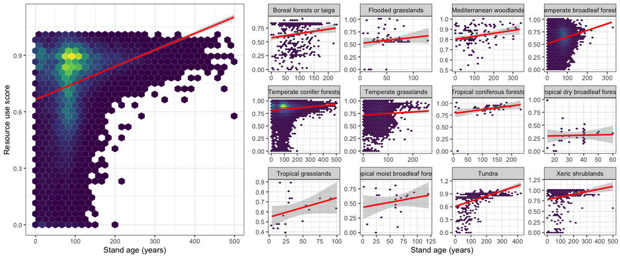

Resource use strategy vs stand age

## Functional Diversity Indices

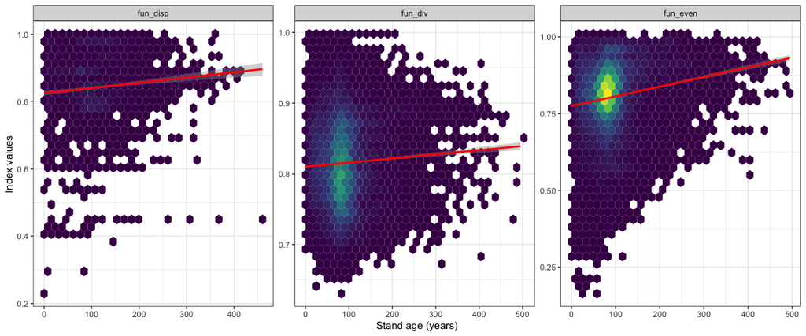

Functional diversity indiced vs stand age

## Weighted Trait Means

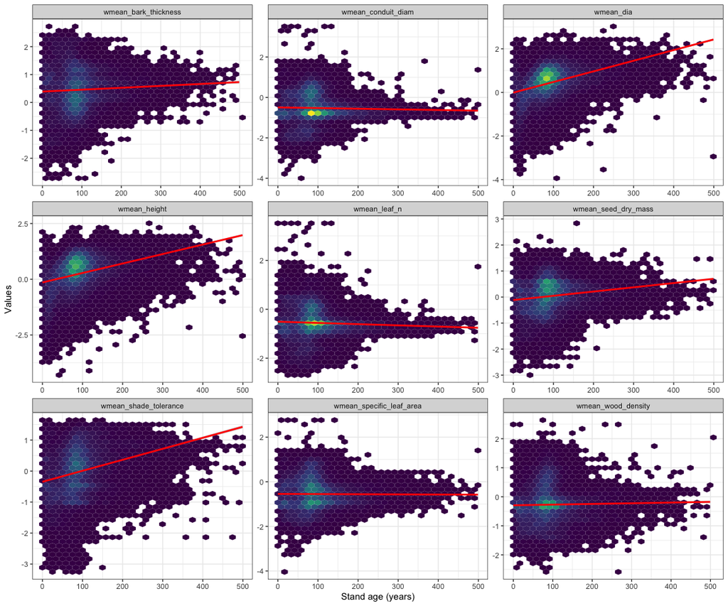

Trait means vs stand age

## Trait standard deviations

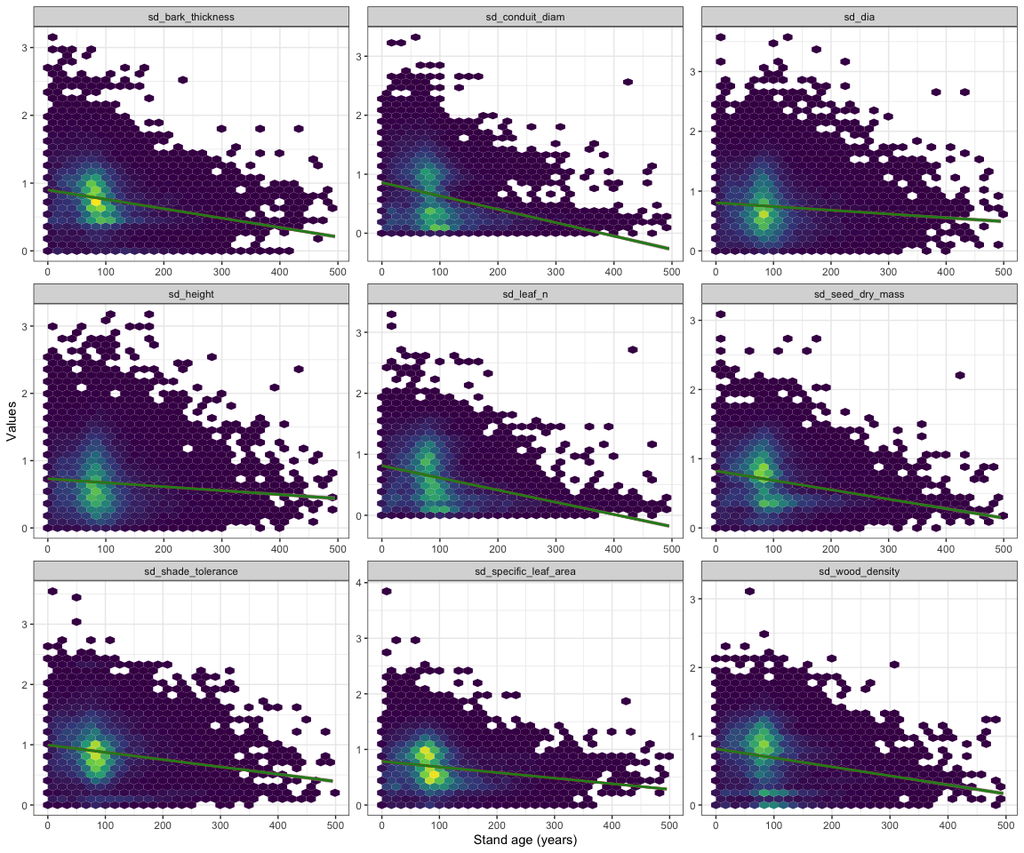

Trait sd vs stand age

## Total Trait Sums

We can also examine summed variables indicating forest extent and mean diameter:

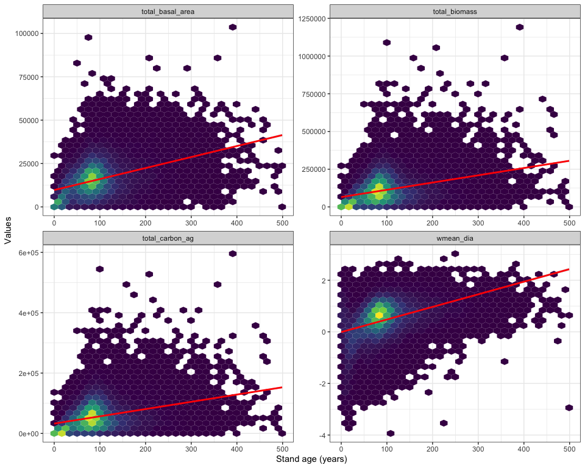